# Advanced Regression Trees

### Loading the dataset and getting the summary statistics

|  | crim | zn | indus | chas | nox | rm | age | dis | rad | tax | ptratio | black | lstat | medv |
| --- | --- | --- | --- | --- | --- | --- | --- | --- | --- | --- | --- | --- | --- | --- |
| 1 | 0.00632 | 18 | 2.31 | 0 | 0.538 | 6.575 | 65.2 | 4.0900 | 1 | 296 | 15.3 | 396.90 | 4.98 | 24.0 |
| 2 | 0.02731 | 0 | 7.07 | 0 | 0.469 | 6.421 | 78.9 | 4.9671 | 2 | 242 | 17.8 | 396.90 | 9.14 | 21.6 |
| 3 | 0.02729 | 0 | 7.07 | 0 | 0.469 | 7.185 | 61.1 | 4.9671 | 2 | 242 | 17.8 | 392.83 | 4.03 | 34.7 |
| 4 | 0.03237 | 0 | 2.18 | 0 | 0.458 | 6.998 | 45.8 | 6.0622 | 3 | 222 | 18.7 | 394.63 | 2.94 | 33.4 |
| 5 | 0.06905 | 0 | 2.18 | 0 | 0.458 | 7.147 | 54.2 | 6.0622 | 3 | 222 | 18.7 | 396.90 | 5.33 | 36.2 |
| 6 | 0.02985 | 0 | 2.18 | 0 | 0.458 | 6.430 | 58.7 | 6.0622 | 3 | 222 | 18.7 | 394.12 | 5.21 | 28.7 |

```
##       crim                zn             indus            chas
##  Min.   : 0.00632   Min.   :  0.00   Min.   : 0.46   Min.   :0.00000
##  1st Qu.: 0.08204   1st Qu.:  0.00   1st Qu.: 5.19   1st Qu.:0.00000
##  Median : 0.25651   Median :  0.00   Median : 9.69   Median :0.00000
##  Mean   : 3.61352   Mean   : 11.36   Mean   :11.14   Mean   :0.06917
##  3rd Qu.: 3.67708   3rd Qu.: 12.50   3rd Qu.:18.10   3rd Qu.:0.00000
##  Max.   :88.97620   Max.   :100.00   Max.   :27.74   Max.   :1.00000
##       nox               rm             age              dis
##  Min.   :0.3850   Min.   :3.561   Min.   :  2.90   Min.   : 1.130
##  1st Qu.:0.4490   1st Qu.:5.886   1st Qu.: 45.02   1st Qu.: 2.100
##  Median :0.5380   Median :6.208   Median : 77.50   Median : 3.207
##  Mean   :0.5547   Mean   :6.285   Mean   : 68.57   Mean   : 3.795
##  3rd Qu.:0.6240   3rd Qu.:6.623   3rd Qu.: 94.08   3rd Qu.: 5.188
##  Max.   :0.8710   Max.   :8.780   Max.   :100.00   Max.   :12.127
##       rad              tax           ptratio          black
##  Min.   : 1.000   Min.   :187.0   Min.   :12.60   Min.   :  0.32
##  1st Qu.: 4.000   1st Qu.:279.0   1st Qu.:17.40   1st Qu.:375.38
##  Median : 5.000   Median :330.0   Median :19.05   Median :391.44
##  Mean   : 9.549   Mean   :408.2   Mean   :18.46   Mean   :356.67
##  3rd Qu.:24.000   3rd Qu.:666.0   3rd Qu.:20.20   3rd Qu.:396.23
##  Max.   :24.000   Max.   :711.0   Max.   :22.00   Max.   :396.90
##      lstat            medv
##  Min.   : 1.73   Min.   : 5.00
##  1st Qu.: 6.95   1st Qu.:17.02
##  Median :11.36   Median :21.20
##  Mean   :12.65   Mean   :22.53
##  3rd Qu.:16.95   3rd Qu.:25.00
##  Max.   :37.97   Max.   :50.00
```

```r
#Train and Test Datasets
sample_index<-sample(nrow(Boston),nrow(Boston)*0.7)
Boston_train<-Boston[sample_index,]
Boston_test<-Boston[-sample_index,]
```

- Stepwise regression

```r
nullmodel<-lm(medv~1, data = Boston_train )
fullmodel<-lm(medv~., data = Boston_train )

model_step_both<-step(nullmodel,
                      scope=list(lower=nullmodel,upper=fullmodel),
                      direction = 'forward')
```

```
## Start:  AIC=1564.39
## medv ~ 1
##
##           Df Sum of Sq   RSS    AIC
## + lstat    1   16360.2 12866 1275.9
## + rm       1   14987.1 14239 1311.8
## + ptratio  1    7905.4 21321 1454.7
## + indus    1    7393.2 21833 1463.2
## + tax      1    6864.6 22362 1471.6
## + nox      1    5308.0 23918 1495.4
## + age      1    4862.5 24364 1502.0
## + crim     1    4777.5 24449 1503.2
## + rad      1    4376.7 24850 1509.0
## + zn       1    4083.5 25143 1513.1
## + black    1    3142.1 26084 1526.1
## + dis      1    1809.8 27416 1543.8
## + chas     1     232.9 28993 1563.5
## <none>                 29226 1564.4
##
## Step:  AIC=1275.94
## medv ~ lstat
##
##           Df Sum of Sq     RSS    AIC
## + rm       1   3155.71  9710.3 1178.3
## + ptratio  1   2000.35 10865.7 1218.1
## + dis      1    623.64 12242.4 1260.3
## + age      1    342.02 12524.0 1268.4
## + chas     1    333.68 12532.3 1268.6
## + black    1    249.79 12616.2 1271.0
## + tax      1    173.33 12692.7 1273.1
## + zn       1    105.86 12760.2 1275.0
## + indus    1     84.36 12781.7 1275.6
## + crim     1     75.56 12790.5 1275.8
## <none>                 12866.0 1275.9
## + nox      1     27.45 12838.6 1277.2
## + rad      1      2.04 12864.0 1277.9
##
## Step:  AIC=1178.32
## medv ~ lstat + rm
##
```

[output cut: 109 more lines]

```
##
##         Df Sum of Sq    RSS    AIC
## + chas   1    82.412 6736.1 1066.9
## <none>               6818.5 1069.2
## + age    1    10.272 6808.2 1070.6
## + indus  1     1.376 6817.1 1071.1
##
## Step:  AIC=1066.86
## medv ~ lstat + rm + ptratio + dis + black + nox + rad + tax +
##     zn + crim + chas
##
##         Df Sum of Sq    RSS    AIC
## <none>               6736.1 1066.9
## + age    1    7.4426 6728.6 1068.5
## + indus  1    3.3699 6732.7 1068.7
```

Checking the in-sample error and AIC

```r
summary(model_step_both)
```

```
##
## Call:
## lm(formula = medv ~ lstat + rm + ptratio + dis + black + nox +
##     rad + tax + zn + crim + chas, data = Boston_train)
##
## Residuals:
##      Min       1Q   Median       3Q      Max
## -11.2511  -2.6328  -0.4936   2.0060  25.3439
##
## Coefficients:
##               Estimate Std. Error t value Pr(>|t|)
## (Intercept)  32.312587   5.773815   5.596 4.49e-08 ***
## lstat        -0.581416   0.052991 -10.972  < 2e-16 ***
## rm            3.945821   0.448787   8.792  < 2e-16 ***
## ptratio      -0.941110   0.144581  -6.509 2.69e-10 ***
## dis          -1.426976   0.203561  -7.010 1.28e-11 ***
## black         0.012478   0.003057   4.082 5.55e-05 ***
## nox         -13.514164   4.061635  -3.327 0.000972 ***
## rad           0.298308   0.067593   4.413 1.37e-05 ***
## tax          -0.010938   0.003573  -3.061 0.002381 **
## zn            0.039689   0.014846   2.673 0.007868 **
## crim         -0.100648   0.040298  -2.498 0.012973 *
## chas          2.138291   1.045352   2.046 0.041568 *
## ---
## Signif. codes:  0 '***' 0.001 '**' 0.01 '*' 0.05 '.' 0.1 ' ' 1
##
## Residual standard error: 4.438 on 342 degrees of freedom
## Multiple R-squared:  0.7695, Adjusted R-squared:  0.7621
## F-statistic: 103.8 on 11 and 342 DF,  p-value: < 2.2e-16
```

```r
AIC(model_step_both)
```

```
## [1] 2073.469
```

```r
MSE.LM<-(summary(model_step_both)$sigma)^2

Test.Predict.LM<-predict(model_step_both,newdata =Boston_test )
MSPE.LM<-mean((Boston_test$medv-Test.Predict.LM)^2)
```

- LASSO

```r
lasso_fit = glmnet(x = as.matrix(Boston_train[, -c(which(colnames(Boston_train)=='medv'))]), y = Boston_train$medv, alpha = 1)

cv_lasso_fit<-cv.glmnet(x=as.matrix(
                        Boston_train[,-c(which(colnames(Boston_train)=='medv'))]),
                        y=Boston_train$medv,
                        alpha=1,
                        nfolds=5)
```

In Sample prediction

```r
pred.lasso.train<- predict(lasso_fit, as.matrix(Boston_train[, -c(which(colnames(Boston_train)=='medv'))]), s = cv_lasso_fit$lambda.min)

MSE.Lasso<-mean((Boston_train$medv-pred.lasso.train)^2)


pred.lasso.test<- predict(lasso_fit, as.matrix(Boston_test[, -c(which(colnames(Boston_test)=='medv'))]), s = cv_lasso_fit$lambda.min)

MSPE.Lasso<-mean((Boston_test$medv-pred.lasso.test)^2)
```

# Regression Tree

Growing large tree

```r
boston.largetree <- rpart(formula = medv ~ ., data = Boston_train, cp = 0.001)
```

Pruning

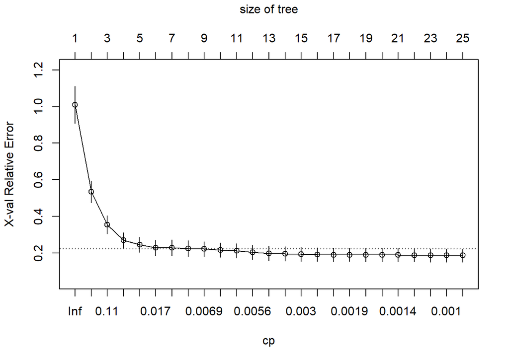

```r
plotcp(boston.largetree)
```

```r
printcp(boston.largetree)
```

```
##
## Regression tree:
## rpart(formula = medv ~ ., data = Boston_train, cp = 0.001)
##
## Variables actually used in tree construction:
## [1] age   black crim  dis   indus lstat nox   rad   rm
##
## Root node error: 29226/354 = 82.56
##
## n= 354
##
##           CP nsplit rel error  xerror     xstd
## 1  0.5161515      0   1.00000 1.00931 0.101301
## 2  0.1774899      1   0.48385 0.53410 0.059790
## 3  0.0678857      2   0.30636 0.35470 0.049697
```

[output cut: 22 more lines]

```r
boston.prunetree<-prune(boston.largetree, cp = 0.02)
```

In sample and out of sample errors

```r
boston.train.pred.tree = predict(boston.prunetree)
MSE.Tree<-mean((Boston_train$medv-boston.train.pred.tree)^2)

boston.test.pred.tree = predict(boston.prunetree,Boston_test)
MSPE.Tree<-mean((Boston_test$medv-boston.test.pred.tree)^2)
```

The out of sample MSPE for the trees is higher than the LASSO model we selected

# Bagging

```r
boston.bag<- randomForest(medv~., data = Boston_train, mtry=13,ntree=100)
```

In sample and out of sample errors

```r
boston.train.pred.Bag = predict(boston.bag)
MSE.Bag<-mean((Boston_train$medv-boston.train.pred.Bag)^2)

boston.bag.pred<-predict(boston.bag,newdata =Boston_test)
MSPE.Bag<-mean((Boston_test$medv-boston.bag.pred)^2)
```

We observe that the MSE and MSPE using the Bagging technique is lower than both single tree and linear regression

Analyze the variation in errors based on the number of trees

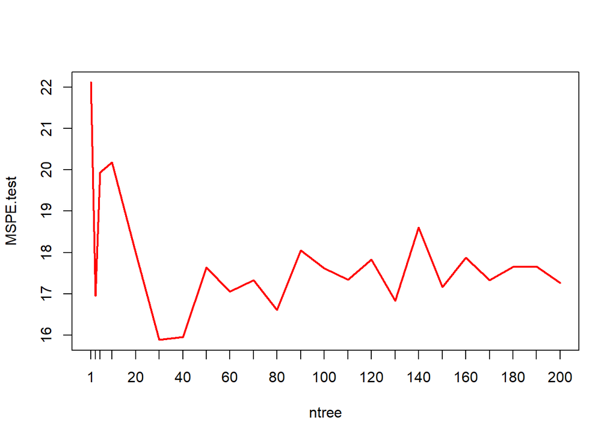

```r
ntree<- c(1, 3, 5, seq(10, 200, 10)) #of bootstraps
MSPE.test<- rep(0, length(ntree)) #initalize the o/p vector

for(i in 1:length(ntree)){
  boston.bag1<- randomForest(medv~., data = Boston_train,mtry=13, ntree=ntree[i])
  boston.bag.pred1<- predict(boston.bag1, newdata = Boston_test)
  MSPE.test[i]<- mean((Boston_test$medv-boston.bag.pred1)^2)
}
plot(ntree,MSPE.test,type='l',col=2,lwd=2,xaxt="n")
axis(1,at=ntree,las=1)
```

```r
optimal.tree = ntree[which(MSPE.test==min(MSPE.test))]
```

Using the optimal value of number of trees

```r
boston.bag<- randomForest(medv~., data = Boston_train, mtry=13,ntree=optimal.tree)
```

In sample and out of sample errors

```r
boston.train.pred.Bag = predict(boston.bag)
MSE.Bag<-mean((Boston_train$medv-boston.train.pred.Bag)^2)

boston.bag.pred<-predict(boston.bag,newdata =Boston_test)
MSPE.Bag<-mean((Boston_test$medv-boston.bag.pred)^2)
```

# Random Forest

```r
boston.rf<- randomForest(medv~., data = Boston_train, importance=TRUE)
boston.rf
```

```
##
## Call:
##  randomForest(formula = medv ~ ., data = Boston_train, importance = TRUE)
##                Type of random forest: regression
##                      Number of trees: 500
## No. of variables tried at each split: 4
##
##           Mean of squared residuals: 11.59262
##                     % Var explained: 85.96
```

In sample and out of sample errors

```r
boston.train.pred.RF= predict(boston.rf)
MSE.RF<-mean((Boston_train$medv-boston.train.pred.RF)^2)

boston.rf.pred<- predict(boston.rf, Boston_test)
MSPE.RF<-mean((Boston_test$medv-boston.rf.pred)^2)
```

Analyze the variation in errors based on the number of variables at each cut

```r
oob.err<- rep(0, 13)
test.err<- rep(0, 13)
ind<-rep(0,13)
for(i in 1:13){
              fit<- randomForest(medv~., data = Boston_train, mtry=i)
              oob.err[i]<- fit$mse[500]
              test.err[i]<- mean((Boston_test$medv-predict(fit, Boston_test))^2)
              cat(i, " ")
              ind[i]<-i
              }
```

```
## 1  2  3  4  5  6  7  8  9  10  11  12  13
```

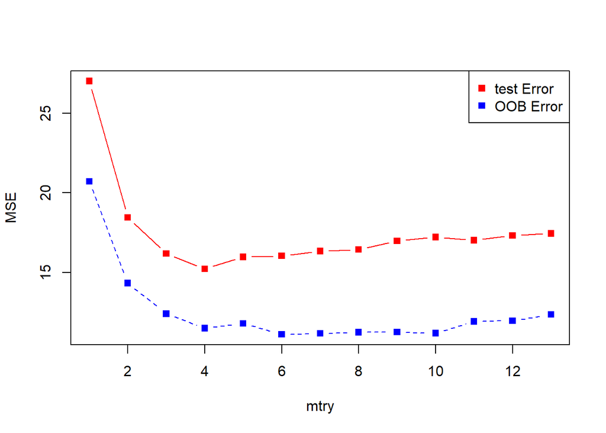

```r
matplot(cbind(test.err, oob.err), pch=15, col = c("red", "blue"), type = "b", ylab = "MSE", xlab = "mtry")
legend("topright", legend = c("test Error", "OOB Error"), pch = 15, col = c("red", "blue"))
```

```r
optimal.var = ind[which(oob.err==min(oob.err))]
```

Using the optimal value of number of variables

```r
boston.rf<- randomForest(medv~., data = Boston_train,
                         importance=TRUE,mtry=optimal.var)
```

In sample and out of sample errors

```r
boston.train.pred.RF= predict(boston.rf)
MSE.RF<-mean((Boston_train$medv-boston.train.pred.RF)^2)


boston.rf.pred<- predict(boston.rf, Boston_test)
MSPE.RF<-mean((Boston_test$medv-boston.rf.pred)^2)
```

# Boosting

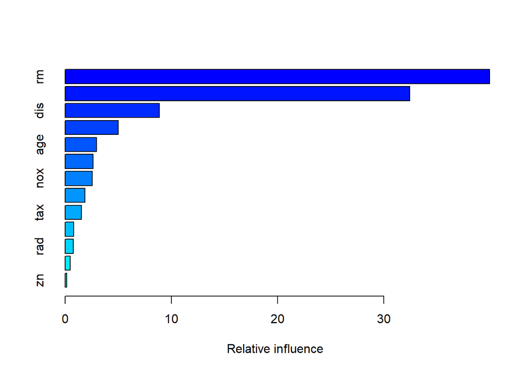

|  | var | rel.inf |
| --- | --- | --- |
| rm | rm | 39.9360074 |
| lstat | lstat | 32.4418379 |
| dis | dis | 8.8792866 |
| crim | crim | 5.0038647 |
| age | age | 2.9654904 |
| black | black | 2.6366888 |
| nox | nox | 2.5662502 |
| ptratio | ptratio | 1.8539500 |
| tax | tax | 1.5261754 |
| indus | indus | 0.7956266 |

[output cut: 3 more lines]

```r
boston.boost<- gbm(medv~., data = Boston_train,
                   distribution = "gaussian",
                   n.trees = 10000,
                   shrinkage = 0.01, #Default is 0.1 which is too high
                   interaction.depth = 8)
summary(boston.boost) #Higher the better
```

In sample and out of sample errors

```r
boston.train.pred.Boost= predict(boston.boost,n.trees = 10000)
MSE.Boost<-mean((Boston_train$medv-boston.train.pred.Boost)^2)

boston.boost.pred.test<- predict(boston.boost, Boston_test, n.trees = 10000)
MSPE.Boost<-mean((Boston_test$medv-boston.boost.pred.test)^2)
```

# Change in MSE with #trees

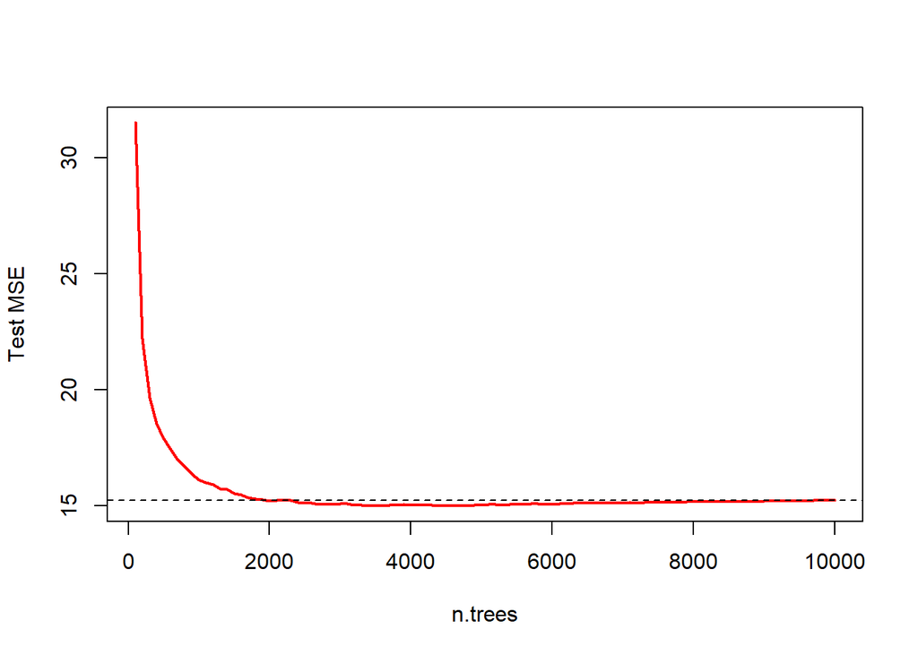

```r
ntree<- seq(100, 10000, 100)
predmat<- predict(boston.boost, newdata = Boston_test, n.trees = ntree)
err<- apply((Boston_test$medv-predmat)^2, 2, mean)
plot(ntree, err, type = 'l', col=2, lwd=2, xlab = "n.trees", ylab = "Test MSE")
abline(h=min(test.err), lty=2)
```

```r
optimal.tree.boost = ntree[which(err==min(err))]
```

Using the optimal value of number of trees

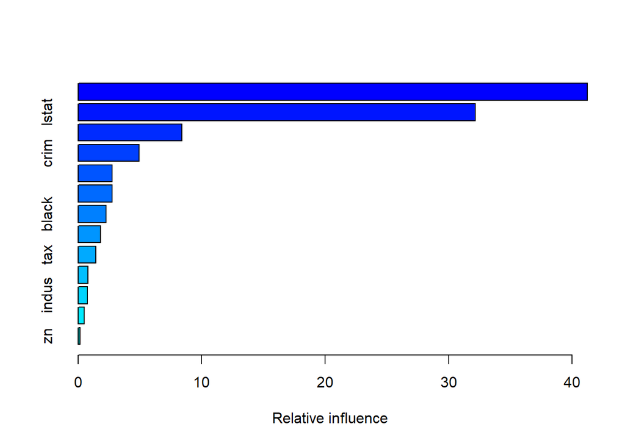

|  | var | rel.inf |
| --- | --- | --- |
| rm | rm | 41.2302019 |
| lstat | lstat | 32.1554289 |
| dis | dis | 8.4035703 |
| crim | crim | 4.9437242 |
| age | age | 2.7644942 |
| nox | nox | 2.7639106 |
| black | black | 2.2703848 |
| ptratio | ptratio | 1.8207414 |
| tax | tax | 1.4530152 |
| rad | rad | 0.7936100 |

[output cut: 3 more lines]

```r
boston.boost<- gbm(medv~., data = Boston_train,
                   distribution = "gaussian",
                   n.trees = optimal.tree.boost,
                   shrinkage = 0.01, #Default is 0.1 which is too high
                   interaction.depth = 8)
summary(boston.boost) #Higher the better
```

In sample and out of sample errors

```r
boston.train.pred.Boost= predict(boston.boost, n.trees = optimal.tree.boost)
MSE.Boost<-mean((Boston_train$medv-boston.train.pred.Boost)^2)

boston.boost.pred.test<- predict(boston.boost, Boston_test, n.trees = optimal.tree.boost)
MSPE.Boost<-mean((Boston_test$medv-boston.boost.pred.test)^2)
```

# Final Table

```r
Technique<-rbind('Linear Regression', 'Regression Tree', 'Bagging', 'Random Forest', 'Boosting')

MSE<-rbind(MSE.LM,MSE.Tree,MSE.Bag,MSE.RF,MSE.Boost)

MSPE<-rbind(MSPE.LM,MSPE.Tree,MSPE.Bag,MSPE.RF,MSPE.Boost)

Summary<-data.frame(Technique,MSE,MSPE)
Summary
```

|  | Technique | MSE | MSPE |
| --- | --- | --- | --- |
| MSE.LM | Linear Regression | 19.696089 | 29.41944 |
| MSE.Tree | Regression Tree | 14.777127 | 35.73656 |
| MSE.Bag | Bagging | 13.431523 | 17.69591 |
| MSE.RF | Random Forest | 11.200375 | 16.27332 |
| MSE.Boost | Boosting | 0.239649 | 15.12929 |